# IODS course final project

Niko Ilomäki (niko.ilomaki@helsinki.fi)

March 8, 2017

This final project uses the Open University Learning Analytics dataset, which is available from [UCI Machine Learning Repository](https://archive.ics.uci.edu/ml/datasets/Open+University+Learning+Analytics+dataset) and from its [own website](https://analyse.kmi.open.ac.uk/open_dataset). For the purposes of this project, the data was downloaded from UCI. The dataset is released under [CC-BY 4.0](https://creativecommons.org/licenses/by/4.0/) license.

Dataset reference: Kuzilek, J., Hlosta, M., Herrmannova, D., Zdrahal, Z. and Wolff, A. OU Analyse: Analysing At-Risk Students at The Open University. Learning Analytics Review, no. LAK15-1, March 2015, ISSN: 2057-7494.

The dataset describes students and their course performances in the Open University. The centerpiece of the dataset are more than 10 million observations of student interactions with the Open University Virtual Learning Environment (VLE).

The dataset here has already been parsed with script available [in the same repository](https://github.com/NVI/IODS-final/blob/master/data/preprocess_data.R), so it is much more compact at this point. In particular, the VLE interactions have been summarised into simple sums and non-numeric variables have been largely removed.

The goal is to see how well course performance (in terms of final grade) can be understood from a number of numeric factors: number of previous attempts on the course, number of credits being studied at the same time, lateness of course submissions (in terms of meeting deadlines) and number of interactions with different kinds of course materials on the VLE. The methods used will be clustering and classification.

It turned out that the predictive power of these numeric factors was not especially high, which is perhaps not that surprising since people are known to achieve good learning results with a wide variety of methods and many people also submit good solutions and essays even if they are chronically late. Even less surprising is that the data formed neat clusters: if a student finds some resources on the VLE interesting and helpful, it is intuitive that they would seek also other resources on the VLE.

```r
oulad_full <- readRDS("data/oulad.Rds")
```

```r
glimpse(oulad_full)
```

```
## Observations: 25,546
## Variables: 27
## $ code_module           <chr> "AAA", "AAA", "AAA", "AAA", "AAA", "AAA"...
## $ code_presentation     <chr> "2013J", "2013J", "2013J", "2013J", "201...
## $ num_of_prev_attempts  <int> 0, 0, 0, 0, 0, 0, 0, 0, 0, 0, 0, 0, 0, 0...
## $ studied_credits       <int> 240, 60, 60, 60, 60, 60, 120, 90, 60, 60...
## $ final_result          <chr> "Pass", "Pass", "Pass", "Pass", "Pass", ...
## $ lateness              <dbl> 0.0, 0.4, 0.0, 1.0, 0.2, 0.4, 0.4, 0.2, ...
## $ average_ahead_of_time <dbl> 1.8, 0.0, 2.0, -11.4, -2.0, -0.4, -2.6, ...
## $ dataplus              <dbl> 0, 10, 2, 0, 7, 2, 4, 8, 3, 5, 8, 0, 12,...
## $ dualpane              <dbl> 0, 0, 0, 0, 0, 0, 0, 0, 0, 0, 0, 0, 0, 0...
## $ externalquiz          <dbl> 0, 0, 0, 0, 0, 0, 0, 0, 0, 0, 0, 0, 0, 0...
## $ folder                <dbl> 0, 0, 0, 0, 0, 0, 0, 0, 0, 0, 0, 0, 0, 0...
## $ forumng               <dbl> 193, 417, 634, 194, 875, 123, 428, 333, ...
## $ glossary              <dbl> 0, 0, 1, 4, 4, 0, 0, 0, 0, 8, 0, 0, 0, 0...
## $ homepage              <dbl> 138, 324, 432, 204, 512, 320, 295, 476, ...
## $ htmlactivity          <dbl> 0, 0, 0, 0, 0, 0, 0, 0, 0, 0, 0, 0, 0, 0...
## $ oucollaborate         <dbl> 0, 0, 0, 0, 0, 2, 1, 2, 0, 0, 2, 3, 1, 0...
## $ oucontent             <dbl> 553, 537, 836, 494, 900, 915, 508, 714, ...
## $ ouelluminate          <dbl> 0, 0, 0, 0, 0, 0, 0, 0, 0, 0, 0, 0, 0, 0...
## $ ouwiki                <dbl> 0, 0, 0, 0, 0, 0, 0, 0, 0, 0, 0, 0, 0, 0...
## $ page                  <dbl> 0, 0, 0, 0, 0, 0, 0, 0, 0, 0, 0, 0, 0, 0...
## $ questionnaire         <dbl> 0, 0, 0, 0, 0, 0, 0, 0, 0, 0, 0, 0, 0, 0...
## $ quiz                  <dbl> 0, 0, 0, 0, 0, 0, 0, 0, 0, 0, 0, 0, 0, 0...
## $ repeatactivity        <dbl> 0, 0, 0, 0, 0, 0, 0, 0, 0, 0, 0, 0, 0, 0...
## $ resource              <dbl> 13, 12, 19, 45, 11, 8, 16, 19, 6, 16, 6,...
## $ sharedsubpage         <dbl> 0, 0, 0, 0, 0, 0, 0, 0, 0, 0, 0, 0, 0, 0...
## $ subpage               <dbl> 32, 87, 144, 79, 91, 98, 120, 214, 124, ...
## $ url                   <dbl> 5, 48, 90, 14, 45, 24, 56, 128, 82, 60, ...
```

At this point the dataset includes 27 variables: code_module and code_presentation together specify the course instance, num_of_prev_attempts is number of previous attempts on the same course, studied_credits is the number of credits the student is currently studying, final_result (here character, but will be later changed into factors) describes the course grade, lateness is the portion of late submissions (0-1), average_ahead_of_time is average of days between submission and deadline so that negative number means a late submission. The rest of the variables are numbers of interactions with different VLE resources. It should be noted that same students will be present in the data multiple times for different courses.

```r
summary(oulad_full)
```

```
##  code_module        code_presentation  num_of_prev_attempts
##  Length:25546       Length:25546       Min.   :0.0000
##  Class :character   Class :character   1st Qu.:0.0000
##  Mode  :character   Mode  :character   Median :0.0000
##                                        Mean   :0.1448
##                                        3rd Qu.:0.0000
##                                        Max.   :6.0000
##  studied_credits  final_result          lateness
##  Min.   : 30.00   Length:25546       Min.   :0.0000
##  1st Qu.: 60.00   Class :character   1st Qu.:0.0000
##  Median : 60.00   Mode  :character   Median :0.2000
##  Mean   : 76.66                      Mean   :0.3108
##  3rd Qu.: 90.00                      3rd Qu.:0.5000
##  Max.   :630.00                      Max.   :1.0000
##  average_ahead_of_time    dataplus          dualpane
##  Min.   :-187.00       Min.   :  0.000   Min.   : 0.0000
##  1st Qu.:  -1.50       1st Qu.:  0.000   1st Qu.: 0.0000
##  Median :   0.50       Median :  0.000   Median : 0.0000
##  Mean   :  11.08       Mean   :  1.857   Mean   : 0.8051
##  3rd Qu.:   8.00       3rd Qu.:  0.000   3rd Qu.: 0.0000
##  Max.   : 236.00       Max.   :143.000   Max.   :68.0000
##   externalquiz         folder          forumng           glossary
##  Min.   :  0.000   Min.   : 0.000   Min.   :    0.0   Min.   :   0.000
##  1st Qu.:  0.000   1st Qu.: 0.000   1st Qu.:   33.0   1st Qu.:   0.000
##  Median :  0.000   Median : 0.000   Median :  123.0   Median :   0.000
##  Mean   :  2.478   Mean   : 0.212   Mean   :  309.5   Mean   :   3.414
##  3rd Qu.:  0.000   3rd Qu.: 0.000   3rd Qu.:  333.0   3rd Qu.:   0.000
##  Max.   :340.000   Max.   :13.000   Max.   :13154.0   Max.   :2952.000
##     homepage       htmlactivity     oucollaborate       oucontent
##  Min.   :   0.0   Min.   : 0.0000   Min.   :  0.000   Min.   :   0.0
##  1st Qu.:  83.0   1st Qu.: 0.0000   1st Qu.:  0.000   1st Qu.:  31.0
##  Median : 174.0   Median : 0.0000   Median :  0.000   Median : 153.0
##  Mean   : 268.6   Mean   : 0.3347   Mean   :  4.215   Mean   : 435.3
##  3rd Qu.: 338.0   3rd Qu.: 0.0000   3rd Qu.:  3.000   3rd Qu.: 535.0
##  Max.   :7277.0   Max.   :33.0000   Max.   :316.000   Max.   :9308.0
##   ouelluminate         ouwiki             page         questionnaire
##  Min.   :  0.000   Min.   :   0.00   Min.   :  0.000   Min.   : 0.000
##  1st Qu.:  0.000   1st Qu.:   0.00   1st Qu.:  0.000   1st Qu.: 0.000
##  Median :  0.000   Median :   0.00   Median :  0.000   Median : 0.000
##  Mean   :  1.516   Mean   :  34.91   Mean   :  2.405   Mean   : 2.533
##  3rd Qu.:  0.000   3rd Qu.:  25.00   3rd Qu.:  2.000   3rd Qu.: 0.000
##  Max.   :317.000   Max.   :2117.00   Max.   :334.000   Max.   :89.000
##       quiz         repeatactivity        resource       sharedsubpage
##  Min.   :    0.0   Min.   :0.000000   Min.   :   0.00   Min.   :0.000000
##  1st Qu.:    0.0   1st Qu.:0.000000   1st Qu.:  13.00   1st Qu.:0.000000
##  Median :   90.0   Median :0.000000   Median :  27.00   Median :0.000000
##  Mean   :  271.8   Mean   :0.000352   Mean   :  42.58   Mean   :0.006616
##  3rd Qu.:  303.0   3rd Qu.:0.000000   3rd Qu.:  53.00   3rd Qu.:0.000000
##  Max.   :13032.0   Max.   :4.000000   Max.   :5147.00   Max.   :6.000000
##     subpage            url
##  Min.   :   0.0   Min.   :   0.00
##  1st Qu.:  25.0   1st Qu.:   3.00
##  Median :  66.0   Median :  10.00
##  Mean   : 131.7   Mean   :  21.84
##  3rd Qu.: 178.0   3rd Qu.:  28.00
##  Max.   :4345.0   Max.   :2134.00
```

While the dataset has been condensed already, it still contains data for multiple courses:

```r
oulad_full %>% group_by(code_module, code_presentation) %>% tally(sort=TRUE)
```

```
## Source: local data frame [22 x 3]
## Groups: code_module [7]
##
##    code_module code_presentation     n
##          <chr>             <chr> <int>
## 1          CCC             2014J  1979
## 2          FFF             2013J  1846
## 3          FFF             2014J  1805
## 4          BBB             2014J  1792
## 5          BBB             2013J  1682
## 6          DDD             2013J  1476
## 7          CCC             2014B  1414
## 8          DDD             2014J  1382
## 9          FFF             2013B  1365
## 10         BBB             2013B  1361
## # ... with 12 more rows
```

To avoid comparing apples with oranges, we will from now on focus solely on the course instance with most observations: CCC/2014J. Cross-analysis between courses would be interesting, but it is not done here.

```r
oulad <- oulad_full %>% filter(code_module == "CCC", code_presentation == "2014J") %>% select(-code_module, -code_presentation)
```

We should investigate whether this course instance uses all of the VLE variety and remove unrelevant activities, if needed:

```r
non_vle_variables <- c("num_of_prev_attempts", "studied_credits", "final_result", "lateness", "average_ahead_of_time")
oulad %>% select(-one_of(non_vle_variables)) %>% colSums()
```

```
##       dataplus       dualpane   externalquiz         folder        forumng
##              0              0              0              0         385629
##       glossary       homepage   htmlactivity  oucollaborate      oucontent
##              0         436777              0           7149         303933
##   ouelluminate         ouwiki           page  questionnaire           quiz
##              0              0           2331              0        1298839
## repeatactivity       resource  sharedsubpage        subpage            url
##              0         127950              0         186183          16572
```

```r
empty_variables <- c("dataplus", "dualpane", "externalquiz", "folder", "glossary", "htmlactivity", "ouelluminate", "ouwiki", "questionnaire", "repeatactivity", "sharedsubpage")
oulad %<>% select(-one_of(empty_variables))
```

Now that there are less observations and less variables, another look at the summary could be beneficial:

```r
summary(oulad)
```

```
##  num_of_prev_attempts studied_credits  final_result          lateness
##  Min.   :0.00000      Min.   : 30.00   Length:1979        Min.   :0.0000
##  1st Qu.:0.00000      1st Qu.: 60.00   Class :character   1st Qu.:0.5000
##  Median :0.00000      Median : 60.00   Mode  :character   Median :0.6667
##  Mean   :0.08691      Mean   : 74.06                      Mean   :0.7233
##  3rd Qu.:0.00000      3rd Qu.: 90.00                      3rd Qu.:1.0000
##  Max.   :1.00000      Max.   :270.00                      Max.   :1.0000
##  average_ahead_of_time    forumng          homepage      oucollaborate
##  Min.   :-50.750       Min.   :   0.0   Min.   :   3.0   Min.   :  0.000
##  1st Qu.: -3.000       1st Qu.:   8.0   1st Qu.:  65.5   1st Qu.:  0.000
##  Median : -2.000       Median :  38.0   Median : 135.0   Median :  0.000
##  Mean   : -2.163       Mean   : 194.9   Mean   : 220.7   Mean   :  3.612
##  3rd Qu.: -1.250       3rd Qu.: 146.0   3rd Qu.: 254.0   3rd Qu.:  2.000
##  Max.   : 21.500       Max.   :6796.0   Max.   :7059.0   Max.   :316.000
##    oucontent           page             quiz            resource
##  Min.   :   0.0   Min.   : 0.000   Min.   :    0.0   Min.   :   0.00
##  1st Qu.:   5.0   1st Qu.: 0.000   1st Qu.:  173.0   1st Qu.:  17.00
##  Median :  33.0   Median : 0.000   Median :  384.0   Median :  41.00
##  Mean   : 153.6   Mean   : 1.178   Mean   :  656.3   Mean   :  64.65
##  3rd Qu.: 140.0   3rd Qu.: 2.000   3rd Qu.:  778.5   3rd Qu.:  77.00
##  Max.   :6170.0   Max.   :19.000   Max.   :13032.0   Max.   :4562.00
##     subpage            url
##  Min.   :  0.00   Min.   :  0.000
##  1st Qu.: 31.00   1st Qu.:  2.000
##  Median : 69.00   Median :  5.000
##  Mean   : 94.08   Mean   :  8.374
##  3rd Qu.:131.00   3rd Qu.: 10.000
##  Max.   :750.00   Max.   :573.000
```

We can also a look at pair plot:

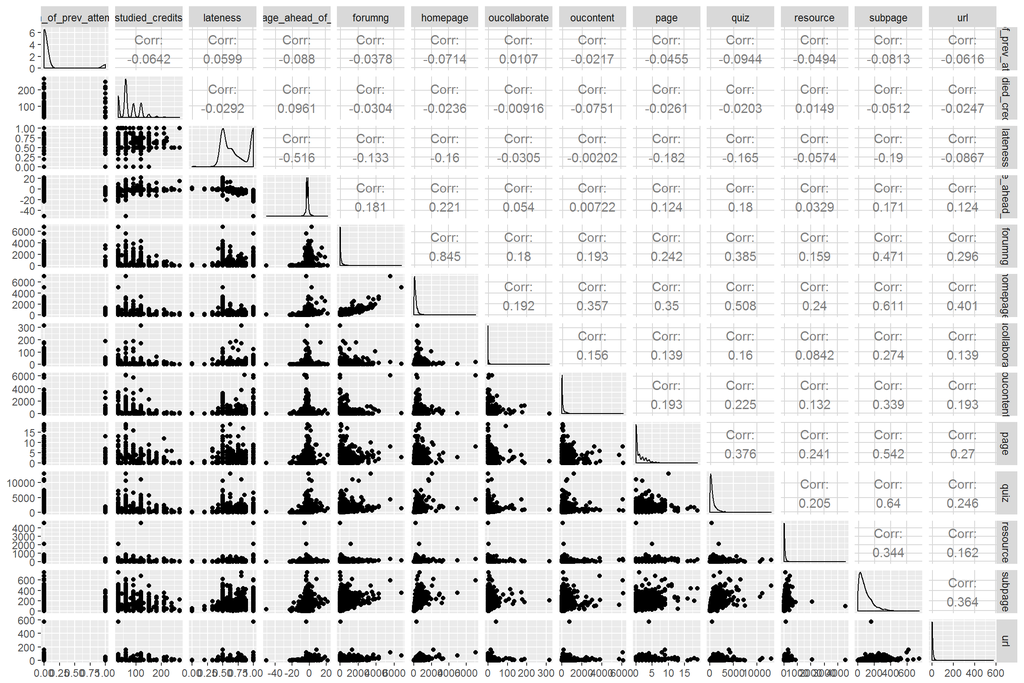

```r
oulad %>% select(-final_result) %>% ggpairs(lower = list(combo = wrap("facethist", bins = 25)))
```

For classification the dataset includes the final result (“Distinction”, “Pass”, “Fail”, “Withdrawn”) variable that we will target with linear discriminant analysis. For practical purposes we will change the final result variable to factor of single letters (“D”, “P”, “F”, “W”). We will also scale the data so that all variables have same mean and variance:

```r
oulad_result <- oulad$final_result %>% substr(1, 1) %>% factor(levels = c("D", "P", "F", "W"))
oulad_scaled <- oulad %>% select(-final_result) %>% scale() %>% as_tibble()
oulad_scaled$final_result <- oulad_result
```

```r
summary(oulad_scaled)
```

```
##  num_of_prev_attempts studied_credits      lateness
##  Min.   :-0.3084      Min.   :-1.1197   Min.   :-3.2207
##  1st Qu.:-0.3084      1st Qu.:-0.3573   1st Qu.:-0.9944
##  Median :-0.3084      Median :-0.3573   Median :-0.2522
##  Mean   : 0.0000      Mean   : 0.0000   Mean   : 0.0000
##  3rd Qu.:-0.3084      3rd Qu.: 0.4052   3rd Qu.: 1.2320
##  Max.   : 3.2404      Max.   : 4.9796   Max.   : 1.2320
##  average_ahead_of_time    forumng           homepage
##  Min.   :-16.84724     Min.   :-0.4017   Min.   :-0.6574
##  1st Qu.: -0.29033     1st Qu.:-0.3852   1st Qu.:-0.4687
##  Median :  0.05641     Median :-0.3234   Median :-0.2588
##  Mean   :  0.00000     Mean   : 0.0000   Mean   : 0.0000
##  3rd Qu.:  0.31647     3rd Qu.:-0.1007   3rd Qu.: 0.1005
##  Max.   :  8.20484     Max.   :13.6092   Max.   :20.6490
##  oucollaborate       oucontent             page              quiz
##  Min.   :-0.2635   Min.   :-0.38700   Min.   :-0.5899   Min.   :-0.7371
##  1st Qu.:-0.2635   1st Qu.:-0.37440   1st Qu.:-0.5899   1st Qu.:-0.5428
##  Median :-0.2635   Median :-0.30385   Median :-0.5899   Median :-0.3058
##  Mean   : 0.0000   Mean   : 0.00000   Mean   : 0.0000   Mean   : 0.0000
##  3rd Qu.:-0.1176   3rd Qu.:-0.03422   3rd Qu.: 0.4118   3rd Qu.: 0.1372
##  Max.   :22.7906   Max.   :15.16080   Max.   : 8.9261   Max.   :13.8985
##     resource           subpage             url           final_result
##  Min.   :-0.48746   Min.   :-1.0544   Min.   :-0.50230   D:306
##  1st Qu.:-0.35928   1st Qu.:-0.7070   1st Qu.:-0.38233   P:706
##  Median :-0.17834   Median :-0.2811   Median :-0.20238   F:363
##  Mean   : 0.00000   Mean   : 0.0000   Mean   : 0.00000   W:604
##  3rd Qu.: 0.09308   3rd Qu.: 0.4138   3rd Qu.: 0.09754
##  Max.   :33.90758   Max.   : 7.3513   Max.   :33.86848
```

We will next divide the data into train and test sets. For replicability, we will set a constant seed before using randomization.

```r
set.seed(1)
idx <- sample(nrow(oulad_scaled), .8*nrow(oulad_scaled))
train <- oulad_scaled[idx, ]
test <- oulad_scaled[-idx, ]
```

Now we are ready to fit LDA to the train set:

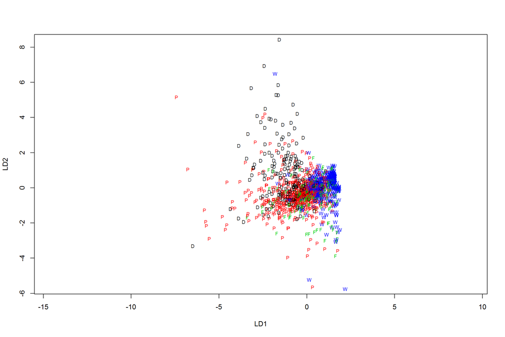

```r
lda.fit <- lda(final_result ~ ., data = train)
plot(lda.fit, dimen = 2, col = as.numeric(train$final_result))
```

The result is not especially neat, though arguably Distinction and Withdrawn grades constrast with the others here. It would seem that the predictive power is limited, and indeed we can make predictions with this LDA:

```r
observed_result <- test$final_result
test %<>% select(-final_result)
predicted_result <- predict(lda.fit, newdata = test)
table(observed_result, predicted_result$class)
```

```
##
## observed_result  D  P  F  W
##               D 16 36  1  7
##               P 10 91  6 32
##               F  0 35  4 37
##               W  0 17  8 96
```

The model gives a lot of wrong predictions so it should be rethought or abandoned altogether. Removing Withdrawn grades would likely improve the results considerably, but then there is also less to explain.

Finally we can look at K-means clustering with the data (removing the grade variable):

```r
oulad_kmeans <- oulad_scaled %>% select(-final_result)
oulad_dist <- dist(oulad_kmeans)
```

We should take a brief look at the choice of number of centers:

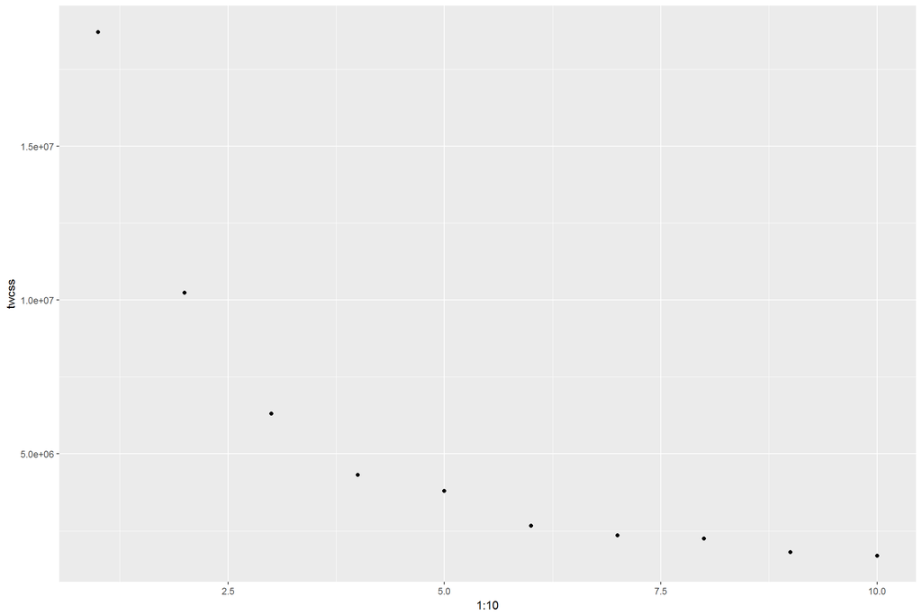

```r
twcss <- sapply(1:10, function(.) {kmeans(oulad_dist, .)$tot.withinss})
qplot(1:10, twcss)
```

All choices from 2 to 4 are reasonable. We will try with 4 centers:

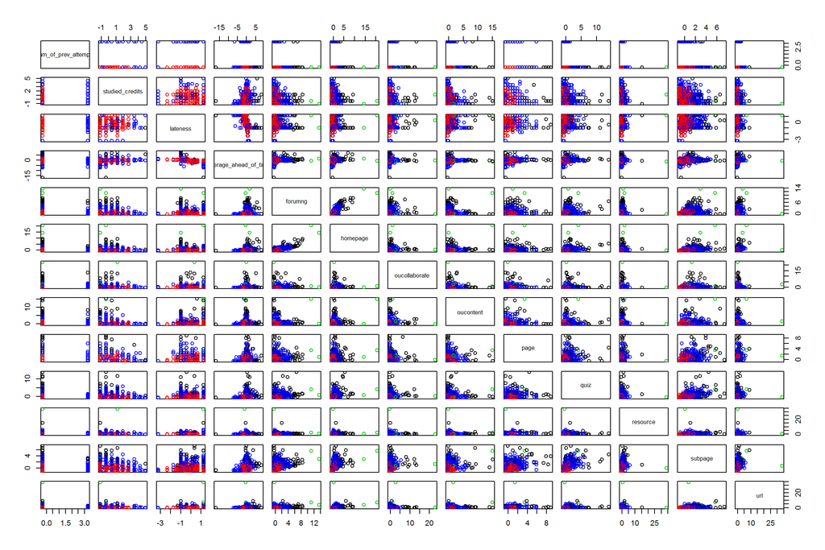

```r
km4 <- kmeans(oulad_dist, centers = 4)
pairs(oulad_kmeans, col = km4$cluster)
```

The data forms neat clusters, which is not surprising given that most variables are related to the VLE service, where usage of some resources is intuitive to lead to usage of other resources as well.